# state farm challenge

## Table of context

1. Load packages
2. Load datasets
3. Overview of train and test sets
4. Data preprocessing  
   4.1 Categorical features preprocessing  
   4.2 Handling missing values
5. Exploratory data analysis  
   5.1 Imbalanced target  
   5.2 Categorical featues  
   5.3 Numerical Features
6. Feature selection  
   6.1 Label encoder for categorical features  
   6.2 Split train into new train and validation  
   6.3 Recursive feature elimination with cross validation
7. Data modeling  
   7.1 RandomForest Classifier  
   7.2 Light GBM Classifier  
   7.3 Summary of models
8. Prediction  
   8.1 Prediciton on test with two models  
   8.2 Write into CSV file
9. Conclusion

## Load packages

```python
import warnings
warnings.filterwarnings('ignore')

import pandas as pd
import numpy as np

import matplotlib.pyplot as plt
import seaborn as sns
from matplotlib.legend_handler import HandlerLine2D

from sklearn.feature_extraction.text import CountVectorizer
from sklearn.preprocessing import OneHotEncoder
%matplotlib inline

from sklearn.preprocessing import OrdinalEncoder
from sklearn.preprocessing import LabelEncoder
from sklearn.feature_selection import RFECV ## feature selection

from sklearn.impute import SimpleImputer
from statistics import mean, median

from sklearn.model_selection import train_test_split
from sklearn.ensemble import RandomForestClassifier
import lightgbm as lgb
from lightgbm import LGBMClassifier
from bayes_opt import BayesianOptimization
from sklearn.model_selection import cross_val_score,StratifiedKFold

from sklearn.metrics import (confusion_matrix, precision_recall_curve, auc,
                             roc_curve, recall_score, classification_report, f1_score,
                             precision_recall_fscore_support)
```

## Load datasets

```python
train=pd.read_csv('../Data/exercise_01_train.csv')
test=pd.read_csv('../Data/exercise_01_test.csv')
```

## Overview of train and test sets

Since the model built on the train set should be generalized to the test set, we should check if the train set is representive or not. Therefore, I would like to check if the distributions of numerical features and missing patterns are similiar in both train and test sets.

```python
print('train shape:', train.shape)
display(train.head())

print('test shape:', test.shape)
display(test.head())
```

```
train shape: (40000, 101)
```

|  | x0 | x1 | x2 | x3 | x4 | x5 | x6 | x7 | x8 | x9 | ... | x91 | x92 | x93 | x94 | x95 | x96 | x97 | x98 | x99 | y |
| --- | --- | --- | --- | --- | --- | --- | --- | --- | --- | --- | --- | --- | --- | --- | --- | --- | --- | --- | --- | --- | --- |
| 0 | 10.142889 | -15.675620 | 3.583176 | -22.397489 | 27.221894 | -34.110924 | -0.072829 | -0.544444 | 0.997601 | -2.691778 | ... | 1.916575 | 5.240820 | euorpe | 2.431170 | 0.454074 | -18.572032 | -14.291524 | 0.178579 | 18.110170 | 0 |
| 1 | -52.214630 | 5.847135 | -10.902843 | -14.132351 | 20.588574 | 36.107322 | 0.115023 | 0.276093 | -0.699168 | -0.972708 | ... | 0.370941 | -3.794542 | asia | 2.592326 | 31.921833 | 3.317139 | 10.037003 | -1.930870 | -3.486898 | 0 |
| 2 | 67.718500 | 2.064334 | 12.394186 | -18.667102 | 47.465504 | -50.373658 | 0.253707 | 1.068968 | 2.939713 | 2.691218 | ... | 1.449817 | 12.470532 | asia | 7.143821 | 9.401490 | -10.604968 | 7.643215 | -0.842198 | -79.358236 | 0 |
| 3 | -28.003111 | 8.565128 | -8.592092 | 5.918960 | -3.224154 | 78.315783 | -0.879845 | 1.176889 | -2.414752 | 0.589646 | ... | -3.274733 | 3.484450 | asia | -4.998195 | -20.312810 | 14.818524 | -9.180674 | 1.356972 | 14.475681 | 0 |
| 4 | 80.703016 | 30.736353 | -30.101857 | -21.201140 | -91.946233 | -47.469246 | -0.646831 | -0.578398 | 0.980849 | -1.426112 | ... | -0.644261 | 4.082783 | asia | -0.012556 | -29.334324 | 1.734433 | -12.262072 | -0.043228 | -19.003881 | 0 |

5 rows × 101 columns

```
test shape: (10000, 100)
```

|  | x0 | x1 | x2 | x3 | x4 | x5 | x6 | x7 | x8 | x9 | ... | x90 | x91 | x92 | x93 | x94 | x95 | x96 | x97 | x98 | x99 |
| --- | --- | --- | --- | --- | --- | --- | --- | --- | --- | --- | --- | --- | --- | --- | --- | --- | --- | --- | --- | --- | --- |
| 0 | -23.230884 | -1.809757 | 12.380690 | -4.101199 | -60.760749 | -22.957453 | -1.964078 | -0.631029 | -4.306616 | -4.694198 | ... | -200.759241 | 1.474824 | -8.057325 | asia | 3.418412 | -10.364264 | -18.055341 | -6.236096 | -4.909211 | 47.679903 |
| 1 | 138.561415 | 1.107473 | -19.781009 | -17.584757 | -76.922109 | 71.816830 | -0.418432 | 1.403957 | -5.367051 | 0.039857 | ... | -323.789253 | 5.539663 | -1.958140 | asia | -5.208792 | -52.514599 | -0.946514 | -20.699992 | -3.704683 | -35.404859 |
| 2 | -9.243047 | -10.207303 | -7.507803 | 3.152110 | -14.915059 | 30.576213 | -0.378178 | 2.606353 | 1.581679 | 4.802973 | ... | 27.816461 | -0.977431 | 10.324237 | asia | 7.939948 | 19.031967 | 7.961947 | 6.761312 | -1.072949 | 36.075623 |
| 3 | 8.963713 | 17.580528 | 13.884170 | -17.164185 | -33.547539 | 19.288187 | -1.219019 | 5.574611 | -3.879657 | 2.693111 | ... | -374.983643 | -2.631231 | 2.206816 | asia | -8.234822 | -14.077963 | -11.476360 | 15.808888 | 6.361906 | 47.278303 |
| 4 | 27.431028 | -6.232849 | 52.780835 | -7.053903 | 5.679193 | -29.618139 | 1.331833 | 4.425692 | -4.213258 | -0.398755 | ... | -352.113759 | 1.759678 | -7.117473 | asia | 5.998549 | -32.618465 | -11.656808 | -19.310773 | -2.407052 | -54.988928 |

5 rows × 100 columns

```python
print('*** train. describe ***')
display(train.describe())

print('*** test. describe ***')
display(test.describe())
```

```
*** train. describe ***
```

|  | x0 | x1 | x2 | x3 | x4 | x5 | x6 | x7 | x8 | x9 | ... | x90 | x91 | x92 | x94 | x95 | x96 | x97 | x98 | x99 | y |
| --- | --- | --- | --- | --- | --- | --- | --- | --- | --- | --- | --- | --- | --- | --- | --- | --- | --- | --- | --- | --- | --- |
| count | 39986.000000 | 39990.000000 | 39994.000000 | 39990.000000 | 39994.000000 | 39990.000000 | 39993.000000 | 39987.000000 | 39994.000000 | 39993.000000 | ... | 39993.000000 | 39998.000000 | 39994.000000 | 39989.000000 | 39993.000000 | 39985.000000 | 39993.000000 | 39995.000000 | 39987.000000 | 40000.000000 |
| mean | 8.259955 | -3.249786 | 1.030666 | -0.747566 | 0.283820 | -1.773510 | -0.000232 | -0.016107 | -0.651093 | -0.014688 | ... | -14.274809 | 0.011390 | 0.003948 | -0.050510 | -0.007572 | -0.629241 | -1.986671 | 0.036482 | 1.486887 | 0.201175 |
| std | 38.374182 | 15.171131 | 24.732185 | 15.225730 | 42.240018 | 42.124100 | 1.065955 | 3.382644 | 2.947472 | 1.906496 | ... | 154.038206 | 3.311041 | 8.763944 | 4.979690 | 19.238210 | 16.915222 | 14.375663 | 5.633052 | 36.926796 | 0.400884 |
| min | -140.780478 | -64.493908 | -105.388182 | -63.804916 | -158.195975 | -169.237259 | -4.133490 | -12.966970 | -12.037625 | -7.446200 | ... | -674.004008 | -12.807938 | -38.121111 | -21.578977 | -87.669573 | -77.010252 | -57.709983 | -23.588876 | -154.559512 | 0.000000 |
| 25% | -17.800204 | -13.458580 | -15.565461 | -11.078276 | -28.246509 | -30.391354 | -0.723098 | -2.299081 | -2.628856 | -1.299759 | ... | -116.645845 | -2.218739 | -5.925508 | -3.435180 | -12.895717 | -11.948902 | -11.686033 | -3.770599 | -23.559519 | 0.000000 |
| 50% | 8.354662 | -3.386601 | 1.132995 | -0.714888 | 0.292788 | -1.753365 | 0.001105 | -0.003556 | -0.659223 | -0.028170 | ... | -11.471306 | -0.006726 | 0.009306 | -0.037111 | 0.124945 | -0.481374 | -2.026059 | 0.041838 | 1.465346 | 0.000000 |
| 75% | 33.829780 | 6.881661 | 17.677615 | 9.552404 | 28.719663 | 26.844781 | 0.715844 | 2.259972 | 1.322101 | 1.263469 | ... | 90.101751 | 2.238996 | 5.909011 | 3.299108 | 12.988509 | 10.793171 | 7.611660 | 3.840100 | 26.548474 | 0.000000 |
| max | 177.399176 | 62.906822 | 99.394915 | 59.338352 | 179.342581 | 170.894497 | 5.311653 | 16.619445 | 14.994937 | 7.300186 | ... | 603.911528 | 14.982369 | 35.785334 | 20.983463 | 78.785164 | 70.182932 | 60.481075 | 22.759016 | 143.126382 | 1.000000 |

8 rows × 95 columns

```
*** test. describe ***
```

|  | x0 | x1 | x2 | x3 | x4 | x5 | x6 | x7 | x8 | x9 | ... | x89 | x90 | x91 | x92 | x94 | x95 | x96 | x97 | x98 | x99 |
| --- | --- | --- | --- | --- | --- | --- | --- | --- | --- | --- | --- | --- | --- | --- | --- | --- | --- | --- | --- | --- | --- |
| count | 10000.000000 | 9998.000000 | 9997.000000 | 9997.000000 | 9998.000000 | 9999.000000 | 9996.000000 | 10000.000000 | 9999.000000 | 9998.000000 | ... | 9997.000000 | 9999.000000 | 9997.000000 | 9998.000000 | 9999.000000 | 9998.000000 | 9998.000000 | 9994.000000 | 9998.000000 | 9998.000000 |
| mean | 7.659723 | -3.090298 | 1.111079 | -0.738489 | 0.479230 | -1.447082 | 0.007241 | -0.007471 | -0.663452 | -0.029460 | ... | -0.085045 | -12.553631 | -0.029183 | 0.106188 | 0.042943 | -0.052841 | -0.516746 | -1.980873 | 0.006856 | 1.366912 |
| std | 38.154705 | 15.250796 | 24.735211 | 15.361257 | 41.934791 | 41.382954 | 1.059882 | 3.353986 | 2.924507 | 1.875564 | ... | 7.650146 | 153.770688 | 3.302254 | 8.755849 | 4.963094 | 19.370753 | 16.956265 | 14.389074 | 5.646734 | 36.847056 |
| min | -146.942945 | -63.335984 | -96.450383 | -65.740406 | -159.472121 | -160.162736 | -3.971430 | -12.138488 | -11.529654 | -7.123307 | ... | -29.543531 | -650.932883 | -11.116723 | -30.962878 | -21.107893 | -72.418350 | -68.747656 | -56.592853 | -22.510713 | -140.735907 |
| 25% | -18.268008 | -13.301540 | -15.686880 | -11.062302 | -27.693495 | -28.929959 | -0.707804 | -2.248168 | -2.580388 | -1.289821 | ... | -5.202499 | -113.553256 | -2.267247 | -5.816339 | -3.314055 | -13.139888 | -11.894004 | -11.641541 | -3.753639 | -23.599386 |
| 50% | 7.509680 | -3.064799 | 1.764322 | -0.634181 | 0.533755 | -1.152902 | 0.007485 | 0.009257 | -0.666028 | -0.044106 | ... | -0.094181 | -8.809392 | -0.051298 | 0.118928 | 0.078457 | -0.031201 | -0.451612 | -1.871513 | -0.012661 | 1.135668 |
| 75% | 33.186920 | 6.844091 | 17.980219 | 9.692347 | 28.755266 | 26.287108 | 0.704268 | 2.244817 | 1.281501 | 1.234191 | ... | 5.057618 | 92.611044 | 2.218320 | 5.976669 | 3.445492 | 13.201257 | 10.896462 | 7.715663 | 3.780273 | 26.144243 |
| max | 143.801953 | 60.339810 | 90.310926 | 60.732554 | 158.498330 | 148.496327 | 4.298322 | 12.827708 | 10.722596 | 6.945239 | ... | 28.197635 | 536.389169 | 13.169523 | 36.923263 | 18.922542 | 79.970819 | 60.918447 | 56.460670 | 20.832139 | 156.745312 |

8 rows × 94 columns

From the two tables above, the distributions of all numeric features are approximately similiar in both train and test sets.

## Data preprocessing

Extract the categorical columns and numerical columns

```python
# Extracting categorical columns
train_cat = train.select_dtypes(include=['object', 'category'])
categories = list(train_cat.columns)

# Extracting numerica columns
categories.append('y')
numerics = [col for col in train.columns  if col not in categories ]

# remove the target from categories
categories.remove('y')
```

### Categorical features preprocessing

```python
train_cat=train[categories]
test_cat=test[categories]

print('train_cat shape:', train_cat.shape)
display(train_cat.head())

print('test_cat shape:', test_cat.shape)
display(test_cat.head())
```

```
train_cat shape: (40000, 6)
```

|  | x34 | x35 | x41 | x45 | x68 | x93 |
| --- | --- | --- | --- | --- | --- | --- |
| 0 | bmw | wed | $-54.1 | 0.0% | Jun | euorpe |
| 1 | nissan | thur | $-229.32 | 0.01% | July | asia |
| 2 | Honda | wed | $243.68 | -0.01% | July | asia |
| 3 | Toyota | thur | $126.15 | 0.02% | May | asia |
| 4 | bmw | thurday | $877.39 | -0.02% | July | asia |

```
test_cat shape: (10000, 6)
```

|  | x34 | x35 | x41 | x45 | x68 | x93 |
| --- | --- | --- | --- | --- | --- | --- |
| 0 | volkswagon | wednesday | $-1073.61 | 0.01% | Jun | asia |
| 1 | volkswagon | thurday | $1775.77 | 0.01% | Jun | asia |
| 2 | Toyota | tuesday | $697.23 | 0.0% | July | asia |
| 3 | volkswagon | wed | $-134.48 | -0.02% | Aug | asia |
| 4 | Toyota | tuesday | $1195.16 | -0.0% | Jun | asia |

From the above talbes, it seems feature engineering should be done for X35, X41 and X45.

#### Clean X35

Change abbreviation into full name. Otherwise there will be extra categoyies for feature x35.

wed = wednesday, fri = friday, thur = thursday

```python
train_cat.x35.unique()
```

```
array(['wed', 'thur', 'thurday', 'wednesday', 'friday', 'tuesday',
       'monday', 'fri', nan], dtype=object)
```

```python
test_cat.x35.unique()
```

```
array(['wednesday', 'thurday', 'tuesday', 'wed', 'thur', 'friday',
       'monday', nan, 'fri'], dtype=object)
```

```python
train_df=train.copy()
train_df.loc[train_df.x35=='fri', 'x35']='friday'
train_df.loc[train_df.x35=='wed', 'x35']='wednesday'
train_df.loc[train_df.x35=='thur', 'x35']='thurday'

test_df=test.copy()
test_df.loc[test_df.x35=='fri', 'x35']='friday'
test_df.loc[test_df.x35=='wed', 'x35']='wednesday'
test_df.loc[test_df.x35=='thur', 'x35']='thurday'
```

#### Clean x68

This step is not necessary for the modeling, but I'd like to clean it.

```python
train_cat.x68.unique()
```

```
array(['Jun', 'July', 'May', 'Aug', 'Apr', 'Mar', 'Oct', 'sept.', 'Nov',
       'Feb', 'Dev', nan, 'January'], dtype=object)
```

```python
test_cat.x68.unique()
```

```
array(['Jun', 'July', 'Aug', 'May', 'Apr', 'sept.', 'Oct', 'Mar', 'Dev',
       'Nov', 'Feb', 'January', nan], dtype=object)
```

```python
train_df.loc[train_df.x68=='sept.', 'x68']='Spet'
train_df.loc[train_df.x68=='January', 'x68']='Jan'
train_df.loc[train_df.x68=='Dec', 'x68']='Dec'

test_df.loc[test_df.x68=='sept.', 'x68']='Spet'
test_df.loc[test_df.x68=='January', 'x68']='Jan'
test_df.loc[test_df.x68=='Dev', 'x68']='Dec'
```

#### Change x41, x45 into numerical values

```python
# change x41 from string into numeric. eg:$-54.10 to -54.10
train_df['x41']=train_df.x41.map(lambda x: x if type(x) == float else float(x.strip('$')))
test_df['x41']=test_df.x41.map(lambda x: x if type(x) == float else float(x.strip('$')))

# change x45 from string into numeric. eg: 0.1% = 0.1

train_df['x45']=train_df.x45.map(lambda x: x if type(x) == float else float(x.strip('%')))
test_df['x45']=test_df.x45.map(lambda x: x if type(x) == float else float(x.strip('%')))
```

Unpate lists of numerics and categories

```python
## update the list of numerics
numerics.append('x41')
numerics.append('x45')

## update the list of categories
categories.remove('x41')
categories.remove('x45')
```

### Handling missing values

#### Missing values in categorical features

```python
train_cat_NA=pd.DataFrame(train[categories].isna().sum(), columns=['Count'])
train_cat_NA['% Missing']=100*(train_cat_NA.Count/len(train))
train_cat_NA.sort_values(by = ['% Missing'], ascending = False, na_position = 'first')
```

|  | Count | % Missing |
| --- | --- | --- |
| x35 | 10 | 0.0250 |
| x68 | 9 | 0.0225 |
| x34 | 7 | 0.0175 |
| x93 | 7 | 0.0175 |

```python
test_cat_NA=pd.DataFrame(test[categories].isna().sum(), columns=['Count'])
test_cat_NA['% Missing']=100*(test_cat_NA.Count/len(test))
test_cat_NA.sort_values(by = ['% Missing'], ascending = False, na_position = 'first')
```

|  | Count | % Missing |
| --- | --- | --- |
| x35 | 3 | 0.03 |
| x34 | 2 | 0.02 |
| x68 | 2 | 0.02 |
| x93 | 1 | 0.01 |

Since the missing rates in the four categorical features are quite low, so I'd like to simply fill the missing values with the most frequent values in both train and test.

```python
## fill na with the most_frequent value in train
train_df.loc[train_df.x35.isna(), 'x35']='wednesday'
train_df.loc[train_df.x68.isna(), 'x68']='July'
train_df.loc[train_df.x34.isna(), 'x34']='volkswagon'
train_df.loc[train_df.x93.isna(), 'x93'] ='asia'

## fill na with the most_frequent value in test
test_df.loc[test_df.x35.isna(), 'x35']='wednesday'
test_df.loc[test_df.x68.isna(), 'x68']='July'
test_df.loc[test_df.x34.isna(), 'x34']='volkswagon'
test_df.loc[test_df.x93.isna(), 'x93']='asia'
```

#### Missing values in numerical features

```python
train_num_NA=pd.DataFrame(train_df[numerics].isna().sum(), columns=['Count'])
train_num_NA['% Missing']=100*(train_num_NA.Count/len(train))
train_num_NA.sort_values(by = ['% Missing'], ascending = False, na_position = 'first')
```

|  | Count | % Missing |
| --- | --- | --- |
| x96 | 15 | 0.0375 |
| x0 | 14 | 0.0350 |
| x55 | 14 | 0.0350 |
| x18 | 14 | 0.0350 |
| x13 | 13 | 0.0325 |
| ... | ... | ... |
| x84 | 3 | 0.0075 |
| x37 | 3 | 0.0075 |
| x14 | 3 | 0.0075 |
| x91 | 2 | 0.0050 |
| x43 | 1 | 0.0025 |

96 rows × 2 columns

```python
test_num_NA=pd.DataFrame(test_df[numerics].isna().sum(), columns=['Count'])
test_num_NA['% Missing']=100*(test_num_NA.Count/len(test))
test_num_NA.sort_values(by = ['% Missing'], ascending = False, na_position = 'first')
```

|  | Count | % Missing |
| --- | --- | --- |
| x73 | 7 | 0.07 |
| x97 | 6 | 0.06 |
| x24 | 5 | 0.05 |
| x76 | 4 | 0.04 |
| x48 | 4 | 0.04 |
| ... | ... | ... |
| x7 | 0 | 0.00 |
| x54 | 0 | 0.00 |
| x84 | 0 | 0.00 |
| x38 | 0 | 0.00 |
| x0 | 0 | 0.00 |

96 rows × 2 columns

Since the missing rate in each numerical feature is quite low, so I'd like to simply fill the missing values with train median in both train and test.

Why median? Since there are 96 numerical features and the time limitation, I would not like to check the distribution of each feature carefully. It's much safer to choose median to fill missing values.

```python
for ele in numerics:
    train_df.loc[train_df[ele].isna(), ele]=median(train_df[ele])
    test_df.loc[test_df[ele].isna(), ele]=median(train_df[ele])
```

## Exploratory data analysis

### Imbalanced target

The base rate of y is 20%, so the data set is imbalanced. Must keep this in mind when train models.

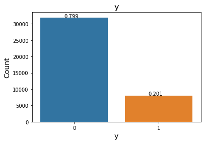

```python
ax1 = sns.countplot(x='y', data=train, order = train.y.value_counts().index)
for p in ax1.patches:
    ax1.annotate('{0:.3}'.format(p.get_height()/len(train)), (p.get_x()+0.28, p.get_height()+0.8))
ax1.set_title("y", fontsize='16')
ax1.set_ylabel('Count', fontsize='14')
ax1.set_xlabel('y',fontsize='14')

plt.show()
```

### Categorical features

#### Distributions of categorical features in train and test

Check if the distribution of each categorical feature is similar in both train and test sets.

```python
def count_plot(col_name, fig_size=(10,10)):
    """
    Helper function for count plot.
    Here in count plot I have ordered by train[col].value_counts so it is easy compare distribution between train and test
    """
    fig = plt.figure(figsize=fig_size)
    fig.add_subplot(2,1,1)
    ax1 = sns.countplot(x=col_name, data=train_df, order = train_df[col_name].value_counts().index)
    for p in ax1.patches:
        ax1.annotate('{0:.3}'.format(p.get_height()/len(train)), (p.get_x()+0.28, p.get_height()+0.8))
    ax1.set_title("Train distribution", fontsize='large')
    ax1.set_ylabel('Count')
    plt.subplots_adjust(wspace =0.8, hspace = 0.5)
    fig.add_subplot(2,1,2)
    ax2 = sns.countplot(x=col_name, data=test_df, order = train_df[col_name].value_counts().index)
    ax2.set_title("Test distribution", fontsize='large')
    ax2.set_ylabel('Count')
    for p in ax2.patches:
        ax2.annotate('{0:.3}'.format(p.get_height()/len(test)), (p.get_x()+0.28, p.get_height()+0.5))

    plt.show()
```

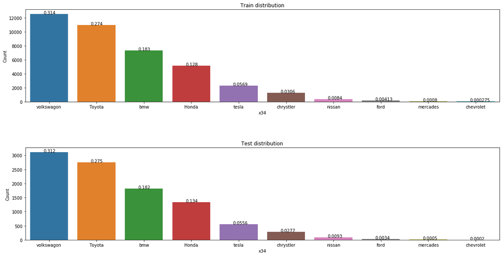

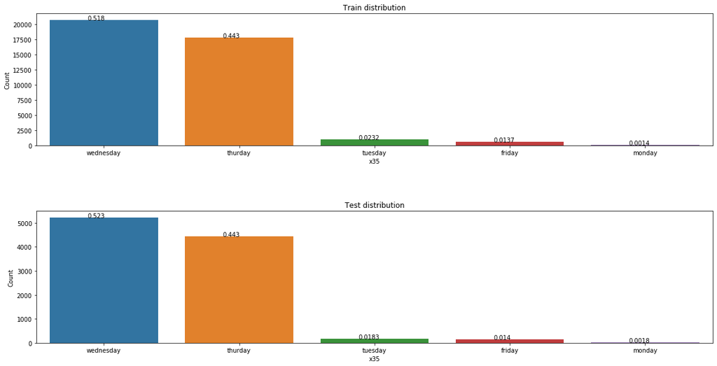

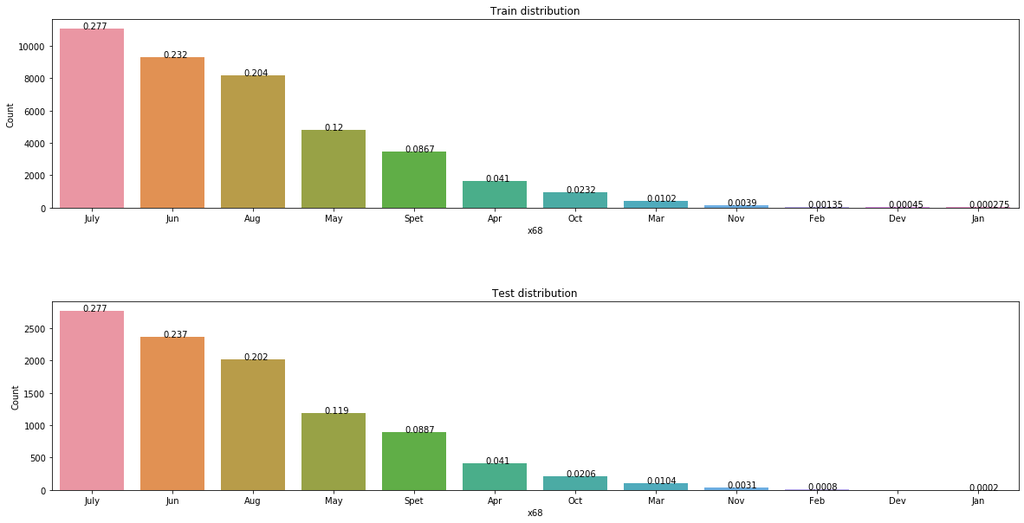

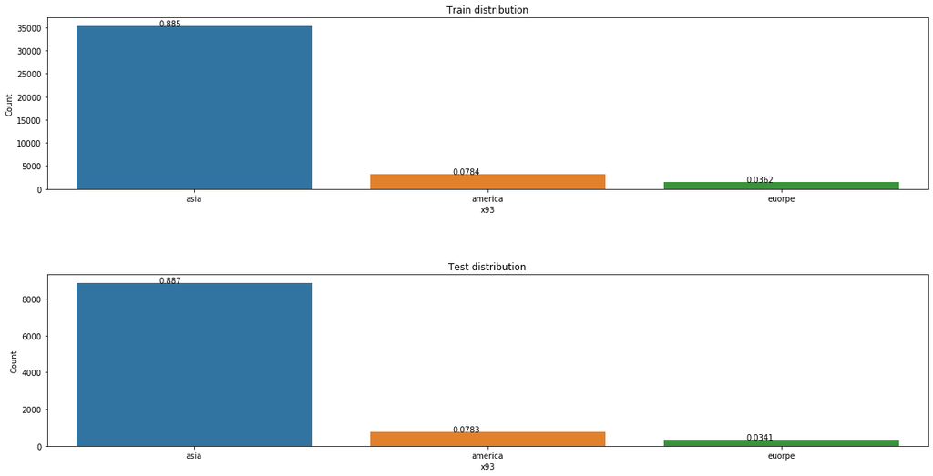

```python
for i in range(4):
    count_plot(col_name =categories[i], fig_size=(20,10))
```

From the output above, the distributions of each feauture are quite similar in both train and test sets. Some counts of categories in each feature are quite low. Grouping the low frequent categories (eg: group 'ford', 'mercades', 'chevrolet' into 'other') may be good for model training. Since the time limitation, I would not like to do grouping.

#### Categorical features VS target

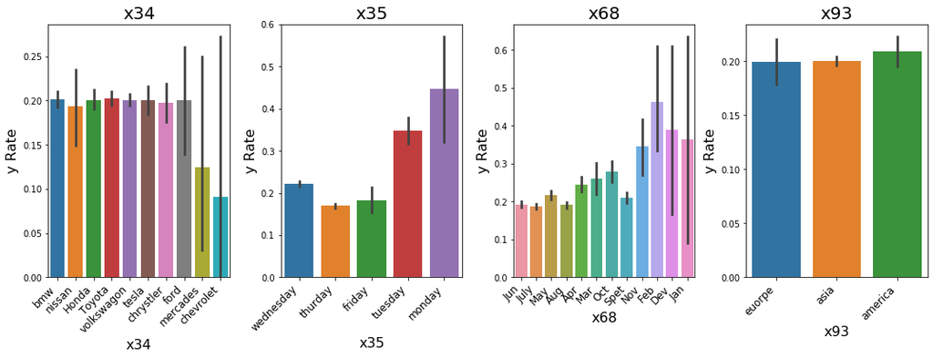

```python
fig= plt.subplots(figsize=(15, 10))

ax1 = plt.subplot2grid((2, 4), (0, 0))
ax2 = plt.subplot2grid((2, 4), (0, 1))
ax3 = plt.subplot2grid((2, 4), (0, 2))
ax4 = plt.subplot2grid((2, 4), (0, 3))

ax=[]
ax.extend((ax1,ax2,ax3,ax4))

plt.subplots_adjust(wspace =0.8, hspace = 1.5) #make the figure look better

for i in range(4):
    sns.barplot(x=train_df[categories[i]], y='y', data=train_df, ax=ax[i])
    ax[i].set_xlabel(categories[i], fontsize=16)
    ax[i].set_ylabel('y Rate', fontsize=16)
    ax[i].set_title(categories[i], fontsize=20)
    plt.setp(ax[i].xaxis.get_majorticklabels(),rotation=45,horizontalalignment='right', fontsize=12)

    plt.tight_layout()
    i += 1

plt.show()
```

From the output above, we can know:

1. the y rate is quite similar for most brands, except mercades and chevrolet. But the error bar is quite large since the counts of these two brands are quite low.
2. the y rate is quite similar before November, and it's comparatively higher in Nov, Dec,Jan and Feb although the error bars are qiute large.
3. the y rate is quite similar in three areas.

### Numerical features

#### Distributions of selected numerical features

Since there are 96 numerical features and the time limitation, I only select several features to explore. I would like to check:

1. the distributions themselves, if it's heavily skewed or not.
2. if the distributions are similar in both train and test

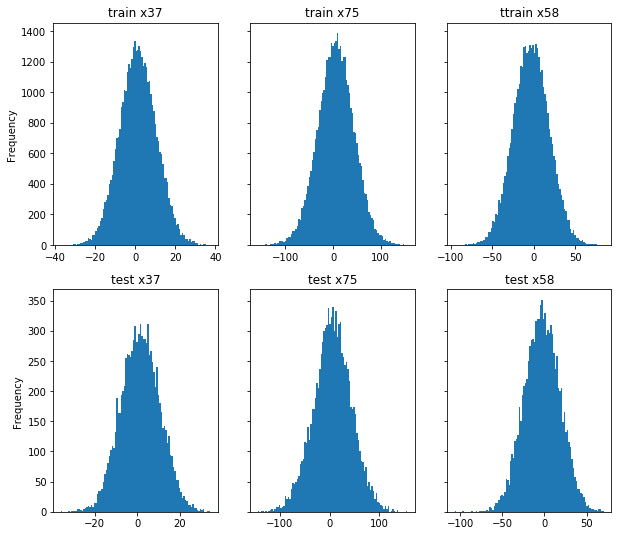

```python
fig, axes = plt.subplots(nrows=2, ncols=3, sharey= 'row', figsize=(10,9))

ax1=axes[0,0]
ax2=axes[0,1]
ax3=axes[0,2]
ax4=axes[1,0]
ax5=axes[1,1]
ax6=axes[1,2]


train.x37.plot(kind='hist', bins=100, ax=ax1, log=False)
train.x75.plot(kind='hist', bins=100,ax=ax2, log=False)
train.x58.plot(kind='hist', bins=100,ax=ax3, log=False)

test.x37.plot(kind='hist', bins=100, ax=ax4, log=False)
test.x75.plot(kind='hist', bins=100,ax=ax5, log=False)
test.x58.plot(kind='hist', bins=100,ax=ax6, log=False)

ax1.title.set_text('train x37')
ax2.title.set_text('train x75')
ax3.title.set_text('ttrain x58')
ax4.title.set_text('test x37')
ax5.title.set_text('test x75')
ax6.title.set_text('test x58')

plt.show()
```

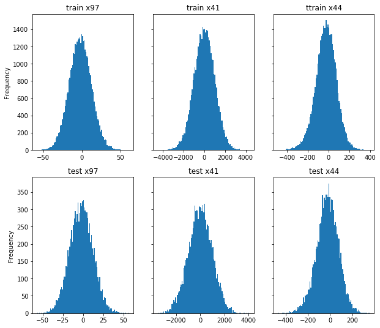

```python
fig, axes = plt.subplots(nrows=2, ncols=3, sharey= 'row', figsize=(10,9))

ax1=axes[0,0]
ax2=axes[0,1]
ax3=axes[0,2]
ax4=axes[1,0]
ax5=axes[1,1]
ax6=axes[1,2]


train.x97.plot(kind='hist', bins=100, ax=ax1, log=False)
train_df.x41.plot(kind='hist', bins=100,ax=ax2, log=False)
train.x44.plot(kind='hist', bins=100,ax=ax3, log=False)

test.x97.plot(kind='hist', bins=100, ax=ax4, log=False)
test_df.x41.plot(kind='hist', bins=100,ax=ax5, log=False)
test.x44.plot(kind='hist', bins=100,ax=ax6, log=False)

ax1.title.set_text('train x97')
ax2.title.set_text('train x41')
ax3.title.set_text('ttrain x44')
ax4.title.set_text('test x97')
ax5.title.set_text('test x41')
ax6.title.set_text('test x44')

plt.show()
```

From the outplots above, most of the distributions are approximately normally distributed, and the distributions checked are quite similar in both train and test.

#### Selected numerical features VS target

x67, x9, x29, x30, x11 and x65 have almost identical distributions in y = 0 and y =1. These features might have very limited impact on target y.

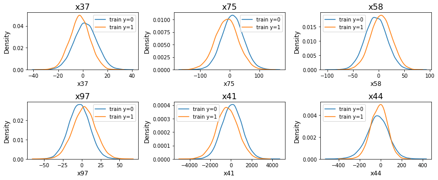

```python
num_ls=['x37', 'x75','x58','x97','x41','x44']
fig= plt.subplots(figsize=(12, 5))
ax1 = plt.subplot2grid((2, 3), (0, 0))
ax2 = plt.subplot2grid((2, 3), (0, 1))
ax3 = plt.subplot2grid((2, 3), (0, 2))
ax4 = plt.subplot2grid((2, 3), (1, 0))
ax5 = plt.subplot2grid((2, 3), (1, 1))
ax6 = plt.subplot2grid((2, 3), (1, 2))

ax=[]
ax.extend((ax1,ax2,ax3, ax4,ax5,ax6))

for i in range(6):
    df = train_df[train_df.y == 0]
    sns.distplot(df[num_ls[i]], hist =False, kde = True, label='train y=0', ax=ax[i])
    df = train_df[train_df.y == 1]
    sns.distplot(df[num_ls[i]], hist =False, kde = True, label='train y=1', ax=ax[i])

    ax[i].set_xlabel(num_ls[i], fontsize=12)
    ax[i].set_ylabel('Density', fontsize=12)
    ax[i].set_title(num_ls[i], fontsize=16)
    plt.tight_layout()
    i += 1

plt.show()
```

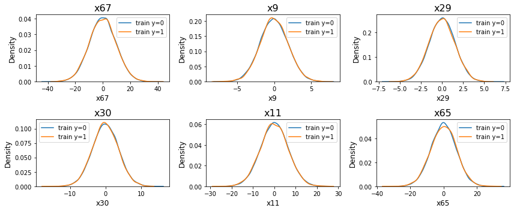

```python
num_ls=['x67', 'x9','x29','x30','x11','x65']
fig= plt.subplots(figsize=(12, 5))
ax1 = plt.subplot2grid((2, 3), (0, 0))
ax2 = plt.subplot2grid((2, 3), (0, 1))
ax3 = plt.subplot2grid((2, 3), (0, 2))
ax4 = plt.subplot2grid((2, 3), (1, 0))
ax5 = plt.subplot2grid((2, 3), (1, 1))
ax6 = plt.subplot2grid((2, 3), (1, 2))

ax=[]
ax.extend((ax1,ax2,ax3, ax4,ax5,ax6))

for i in range(6):
    df = train_df[train_df.y == 0]
    sns.distplot(df[num_ls[i]], hist =False, kde = True, label='train y=0', ax=ax[i])
    df = train_df[train_df.y == 1]
    sns.distplot(df[num_ls[i]], hist =False, kde = True, label='train y=1', ax=ax[i])

    ax[i].set_xlabel(num_ls[i], fontsize=12)
    ax[i].set_ylabel('Density', fontsize=12)
    ax[i].set_title(num_ls[i], fontsize=16)
    plt.tight_layout()
    i += 1

plt.show()
```

#### Correlation among numerical features

To check if there are highly correlated features which would be removed before modeling.

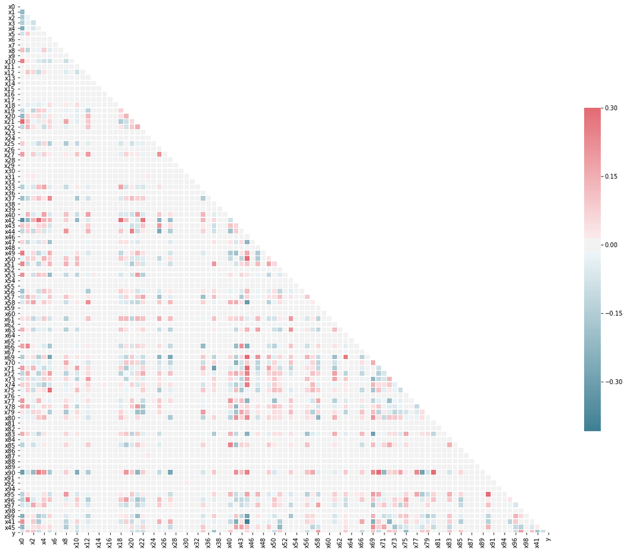

```python
corr=train_df[numerics].corr(method='pearson')

mask = np.zeros_like(corr, dtype=np.bool)
mask[np.triu_indices_from(mask)] = True
f, ax = plt.subplots(figsize=(20, 20))
cmap = sns.diverging_palette(220, 10, as_cmap=True)
sns.heatmap(corr, annot=False,mask=mask, cmap=cmap, vmax=.3, center=0,
            square=True, linewidths=.5, cbar_kws={"shrink": .5})
plt.show()
```

From the about output, there is no highly correlated features.

## Feature selection

### Label encoder for categorical features

```python
print('Transform all String features to category.\n')
for usecol in categories:
    train_df[usecol] = train_df[usecol].astype('str')
    test_df[usecol] = test_df[usecol].astype('str')

    #Fit LabelEncoder
    le = LabelEncoder().fit(
            np.unique(train_df[usecol].unique().tolist()+
                      test_df[usecol].unique().tolist()))

    #At the end 0 will be used for null values so we start at 1
    train_df[usecol] = le.transform(train_df[usecol])+1
    test_df[usecol]  = le.transform(test_df[usecol])+1

    train_df[usecol] = train_df[usecol].replace(np.nan, 0).astype('int').astype('category')
    test_df[usecol]  = test_df[usecol].replace(np.nan, 0).astype('int').astype('category')
```

```
Transform all String features to category.
```

### Split train into new train and validation

```python
X=train_df.copy()
X=X.drop(columns=['y'])
y=train_df.y

X_test=test_df.copy()


## split X_train into training and validation
X_train, X_val, y_train, y_val = train_test_split(X, y, test_size=0.25, random_state=2019)
```

### Recursive feature elimination with cross validation

RandomForest Classifier as the model for selection.

Set up baseline classifier.

```python
## Baseline RandomForestClassifier
rf = RandomForestClassifier(class_weight='balanced') ## Since base rate of shroke is very rare, data should be balanced

rf_baseline_train = cross_val_score(rf, X_train, y_train, scoring='roc_auc', cv=10).mean()
rf_baseline_val = cross_val_score(rf, X_val, y_val, scoring='roc_auc',cv=10).mean()

print('train_rf_baseline ROC_AUC: {0:.3}'.format(rf_baseline_train))
print('val_rf_baseline ROC_AUC: {0:.3}'.format(rf_baseline_val))
```

```
train_rf_baseline ROC_AUC: 0.909
val_rf_baseline ROC_AUC: 0.866
```

Select feature with RFECV

```python
clf = RandomForestClassifier(class_weight = 'balanced')
rfecv = RFECV(estimator=clf, step=1, cv=5,scoring='roc_auc')   #5-fold cross-validation
rfecv = rfecv.fit(X_train, y_train)

print('Optimal number of features :', rfecv.n_features_)
print('Best features :', X_train.columns[rfecv.support_])
```

```
Optimal number of features : 49
Best features : Index(['x0', 'x1', 'x2', 'x3', 'x4', 'x5', 'x8', 'x10', 'x12', 'x19', 'x20',
       'x21', 'x22', 'x25', 'x27', 'x33', 'x37', 'x40', 'x41', 'x43', 'x44',
       'x47', 'x49', 'x50', 'x51', 'x53', 'x56', 'x57', 'x58', 'x61', 'x63',
       'x66', 'x69', 'x70', 'x71', 'x72', 'x73', 'x74', 'x75', 'x77', 'x78',
       'x79', 'x83', 'x85', 'x90', 'x95', 'x96', 'x97', 'x99'],
      dtype='object')
```

Run the model again with best features

```python
best_features=list(X_train.columns[rfecv.support_])
```

```python
X_train_best=X_train.copy()
X_train_best=X_train_best[best_features]

X_val_best=X_val.copy()
X_val_best=X_val_best[best_features]
```

```python
rf_baseline_train = cross_val_score(rf, X_train_best, y_train, scoring='roc_auc', cv=10).mean()
rf_baseline_val = cross_val_score(rf, X_val_best, y_val, scoring='roc_auc',cv=10).mean()

print('After selection  train_rf_baseline ROC_AUC: {0:.3}'.format(rf_baseline_train))
print('After selection  val_rf_baseline ROC_AUC: {0:.3}'.format(rf_baseline_val))
```

```
After selection  train_rf_baseline ROC_AUC: 0.932
After selection  val_rf_baseline ROC_AUC: 0.903
```

The result indicates that the model performance has been improved from AUC 0.866 to AUC 0.903 on validation set.

## Data modeling

### RandomForest Classifier

RandomForest classifier is a tree-based algorithm, it has the following advantages:

1. robust to outliers.
2. quick train/prediction speed.
3. provides the scores about feature importance, which can let you know the relationship features have with the target and the degree of influence they have on target.

#### Tune hyperparameters for RandomForest classifier with BayesianOptimization

What does BayesianOptimization do? Build a probability model of the objective function and use it to select the most promising hyperparameters to evaluate in the true objective function. Advantages compared to GridSearch and RandomSearch:

1. quick tuning speed
2. search space is large and continous

```python
def rf_evaluate( n_estimators, max_depth, min_samples_split, min_samples_leaf,max_leaf_nodes):
    rf_params = {  'n_estimators': int(n_estimators),
                   'max_depth': int(max_depth),
                   'min_samples_split':int(min_samples_split),
                   'min_samples_leaf':int(min_samples_leaf),
                   'max_leaf_nodes':int(max_leaf_nodes),
                   'n_jobs':-1,
                   'random_state':42
               }

    cv_result= cross_val_score(RandomForestClassifier(**rf_params, class_weight='balanced'),  ## ** unpack params for the function call
               X=X_train_best,
               y=y_train,
               cv=10,
               scoring='roc_auc',
               n_jobs=-1).mean()
    return cv_result

rf_params = {"n_estimators": (10, 300),
            "max_depth": (3, 20),
            "min_samples_split": (2, 15),
            'min_samples_leaf':(2,20),
            "max_leaf_nodes": (20, 40)
            }


rf_bo = BayesianOptimization(rf_evaluate , rf_params)
```

```python
rf_bo.maximize(init_points=5, n_iter=5, acq='ei')
```

```
|   iter    |  target   | max_depth | max_le... | min_sa... | min_sa... | n_esti... |
-------------------------------------------------------------------------------------
|  1        |  0.9129   |  5.567    |  22.7     |  4.898    |  9.103    |  228.5    |
|  2        |  0.917    |  19.48    |  25.49    |  5.005    |  14.22    |  110.6    |
|  3        |  0.9077   |  16.03    |  20.04    |  7.394    |  13.47    |  126.7    |
|  4        |  0.9122   |  13.13    |  22.67    |  2.682    |  5.55     |  103.5    |
|  5        |  0.9292   |  5.385    |  36.71    |  7.699    |  12.68    |  266.2    |
|  6        |  0.9322   |  17.76    |  39.71    |  2.119    |  3.406    |  296.4    |
|  7        |  0.8879   |  5.331    |  39.75    |  3.73     |  13.7     |  10.07    |
|  8        |  0.932    |  19.65    |  39.85    |  2.939    |  3.296    |  159.3    |
|  9        |  0.897    |  3.938    |  39.97    |  2.116    |  14.56    |  282.8    |
|  10       |  0.9323   |  20.0     |  40.0     |  20.0     |  2.0      |  256.6    |
=====================================================================================
```

```python
## get the best parameters
rf_params = rf_bo.max['params']

print(rf_params)
```

```
{'max_depth': 20.0, 'max_leaf_nodes': 40.0, 'min_samples_leaf': 20.0, 'min_samples_split': 2.0, 'n_estimators': 256.55998234862795}
```

```python
rf_tuned = RandomForestClassifier(max_depth=20,
                                  min_samples_split=2,
                                  n_estimators= 256,
                                  min_samples_leaf=20,
                                  max_leaf_nodes=40,
                                  class_weight='balanced')

rf_tuned = rf_tuned.fit(X_train_best, y_train)

rf_tuned_train_ROC_AUC = cross_val_score(rf_tuned, X_train_best, y_train, scoring='roc_auc').mean()
rf_tuned_val_ROC_AUC = cross_val_score(rf_tuned, X_val_best, y_val, scoring='roc_auc').mean()

print('train_rf_baseline ROC_AUC: {0:.3}'.format(rf_baseline_train))
print('train_rf_tuned ROC_AUC: {0:.3}'.format(rf_tuned_train_ROC_AUC))

print(' ')

print('val_rf_baseline ROC_AUC: {0:.3}'.format(rf_baseline_val))
print('val_rf_tuned ROC_AUC: {0:.3}'.format(rf_tuned_val_ROC_AUC))
```

```
train_rf_baseline ROC_AUC: 0.932
train_rf_tuned ROC_AUC: 0.936

val_rf_baseline ROC_AUC: 0.903
val_rf_tuned ROC_AUC: 0.932
```

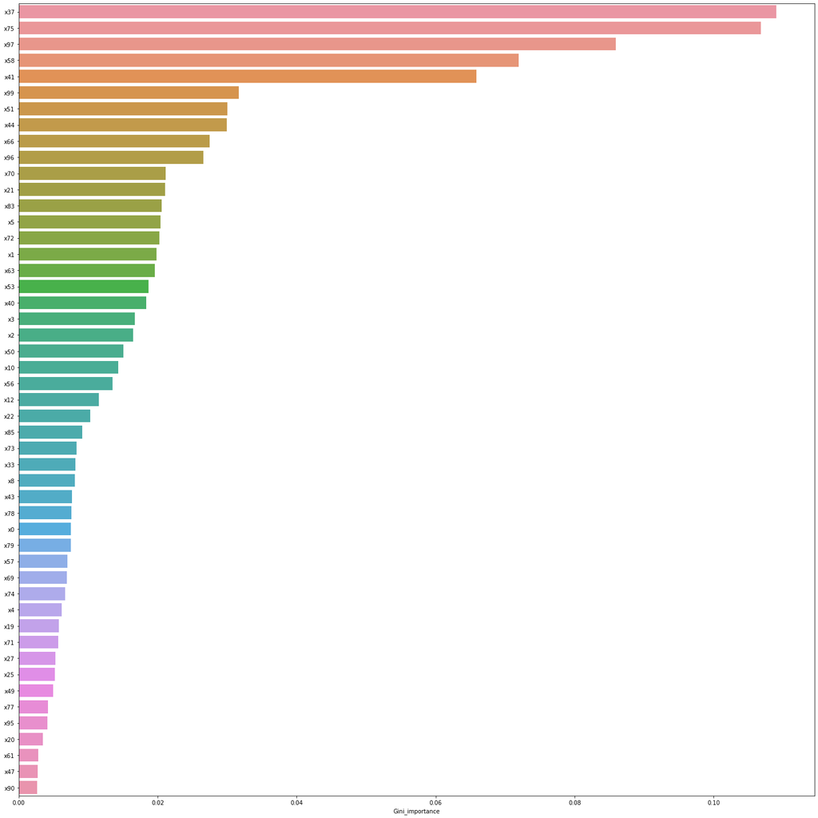

```python
rf_fscores=pd.DataFrame(rf_tuned.feature_importances_)

feats = {} # a dict to hold feature_name: feature_importance
for feature, importance in zip(X_train_best.columns, rf_tuned.feature_importances_):
    feats[feature] = importance #add the name/value pair

rf_importances = pd.DataFrame.from_dict(feats, orient='index').rename(columns={0: 'Gini_importance'})

plt.figure(figsize=(20, 20))
importances=rf_importances.sort_values(by='Gini_importance', ascending=False)
sns.barplot(x='Gini_importance', y=importances.index, data=importances)
plt.tight_layout()
plt.show()
```

The top important features are x37, x75, x97, x58 and x41, which is roughly consistent with the insights based on data visualiztion.

### Light GBM Classifier

Light GBM Classifier is a gradient tree-based algorithm, it has the following advantages:

1. Higher efficiency as well as faster training speed
2. Usage of lower memory
3. Supports Parallel and GPU learning
4. Data of large-scale can be handled

Baseline LGBMClassifier

```python
# Instantiate an LGBMClassifier with default hyperparameter settings
lgb = LGBMClassifier(class_weight='balanced') ## data should be balanced

# compute a baseline to beat with hyperparameter optimization
lgb_baseline_train = cross_val_score(lgb, X_train_best, y_train, scoring='roc_auc', cv=10).mean()
lgb_baseline_val = cross_val_score(lgb, X_val_best, y_val, scoring='roc_auc',cv=10).mean()

print('train_lgb_baseline ROC_AUC: {0:.3}'.format(lgb_baseline_train))
print('val_lgb_baseline ROC_AUC: {0:.3}'.format(lgb_baseline_val))
```

```
train_lgb_baseline ROC_AUC: 0.982
val_lgb_baseline ROC_AUC: 0.977
```

#### Tune hyperparameters for LGBMClassifier with BayesianOptimization

```python
def lgb_evaluate( n_estimators, max_depth, learning_rate, lambda_l1, lambda_l2):
    lgb_params = {  'n_estimators': int(n_estimators),
                   'max_depth': int(max_depth),
                   'learning_rate':learning_rate,
                  'lambda_l1':lambda_l1,
                  'lambda_l2':lambda_l2,
                  'metric':'auc',
                  'objective':'binary',
                  'importance_type':'gain'
               }
    cv_result= cross_val_score(LGBMClassifier(**lgb_params, class_weight='balanced'),  ## ** unpack params for the function call
               X=X_train,
               y=y_train,
               cv=10,
               scoring='roc_auc',
               n_jobs=-1).mean()
    return cv_result

lgb_params = {"n_estimators": (10, 300),
                  "max_depth": (3, 20),
                  'learning_rate':(0.001,0.02),
                  'lambda_l1':(0,5),
                  'lambda_l2':(0,5)
             }


lgb_bo = BayesianOptimization(lgb_evaluate , lgb_params)
```

```python
lgb_bo.maximize(init_points=8, n_iter=8, acq='ei')
```

```
|   iter    |  target   | lambda_l1 | lambda_l2 | learni... | max_depth | n_esti... |
-------------------------------------------------------------------------------------
|  1        |  0.9253   |  2.23     |  4.517    |  0.009826 |  16.08    |  119.6    |
|  2        |  0.801    |  0.8304   |  4.919    |  0.002257 |  19.75    |  19.49    |
|  3        |  0.9207   |  4.02     |  1.978    |  0.004985 |  10.07    |  211.1    |
|  4        |  0.8568   |  0.284    |  1.889    |  0.002327 |  12.91    |  139.6    |
|  5        |  0.9301   |  1.598    |  1.111    |  0.005637 |  6.126    |  235.3    |
|  6        |  0.9637   |  1.586    |  2.604    |  0.01328  |  14.53    |  251.4    |
|  7        |  0.9749   |  1.143    |  3.261    |  0.01819  |  11.96    |  289.5    |
|  8        |  0.8555   |  3.507    |  1.848    |  0.007854 |  4.671    |  72.0     |
|  9        |  0.9764   |  5.0      |  5.0      |  0.02     |  20.0     |  300.0    |
|  10       |  0.9124   |  5.0      |  5.0      |  0.01145  |  3.0      |  288.9    |
|  11       |  0.9781   |  0.0      |  0.0      |  0.02     |  20.0     |  300.0    |
|  12       |  0.9763   |  0.0      |  5.0      |  0.02     |  20.0     |  282.8    |
|  13       |  0.9428   |  0.0      |  0.0      |  0.02     |  20.0     |  88.2     |
|  14       |  0.9725   |  0.0      |  0.0      |  0.02     |  20.0     |  228.0    |
|  15       |  0.8499   |  5.0      |  0.0      |  0.001    |  19.82    |  283.3    |
|  16       |  0.9774   |  0.0      |  5.0      |  0.02     |  12.33    |  300.0    |
=====================================================================================
```

```python
## get the best parameters
lgb_params = lgb_bo.max['params']

print(lgb_params)
```

```
{'lambda_l1': 0.0, 'lambda_l2': 0.0, 'learning_rate': 0.019999999942632803, 'max_depth': 20.0, 'n_estimators': 300.0}
```

```python
lgb_tuned = LGBMClassifier( learning_rate= 0.019999999942632803,
                                   max_depth= 20,
                                   n_estimators=300,
                                   lambda_l1=0,
                                   lambda_l2=0,
                                   class_weight='balanced',
                                   importance_type='gain',
                                   objective='binary'
                          )

lgb_tuned = lgb_tuned.fit(X_train_best, y_train)

lgb_tuned_train_ROC_AUC = cross_val_score(lgb_tuned, X_train_best, y_train, scoring='roc_auc', cv=10).mean()
lgb_tuned_val_ROC_AUC = cross_val_score(lgb_tuned, X_val_best, y_val, scoring='roc_auc',cv=10).mean()

print('train_lgb_baseline ROC_AUC: {0:.3}'.format(lgb_baseline_train))
print('train_lgb_tuned ROC_AUC: {0:.3}'.format(lgb_tuned_train_ROC_AUC))

print(' ')

print('val_lgb_baseline ROC_AUC: {0:.3}'.format(lgb_baseline_val))
print('val_lgb_tuned ROC_AUC: {0:.3}'.format(lgb_tuned_val_ROC_AUC))
```

```
train_lgb_baseline ROC_AUC: 0.982
train_lgb_tuned ROC_AUC: 0.977

val_lgb_baseline ROC_AUC: 0.977
val_lgb_tuned ROC_AUC: 0.97
```

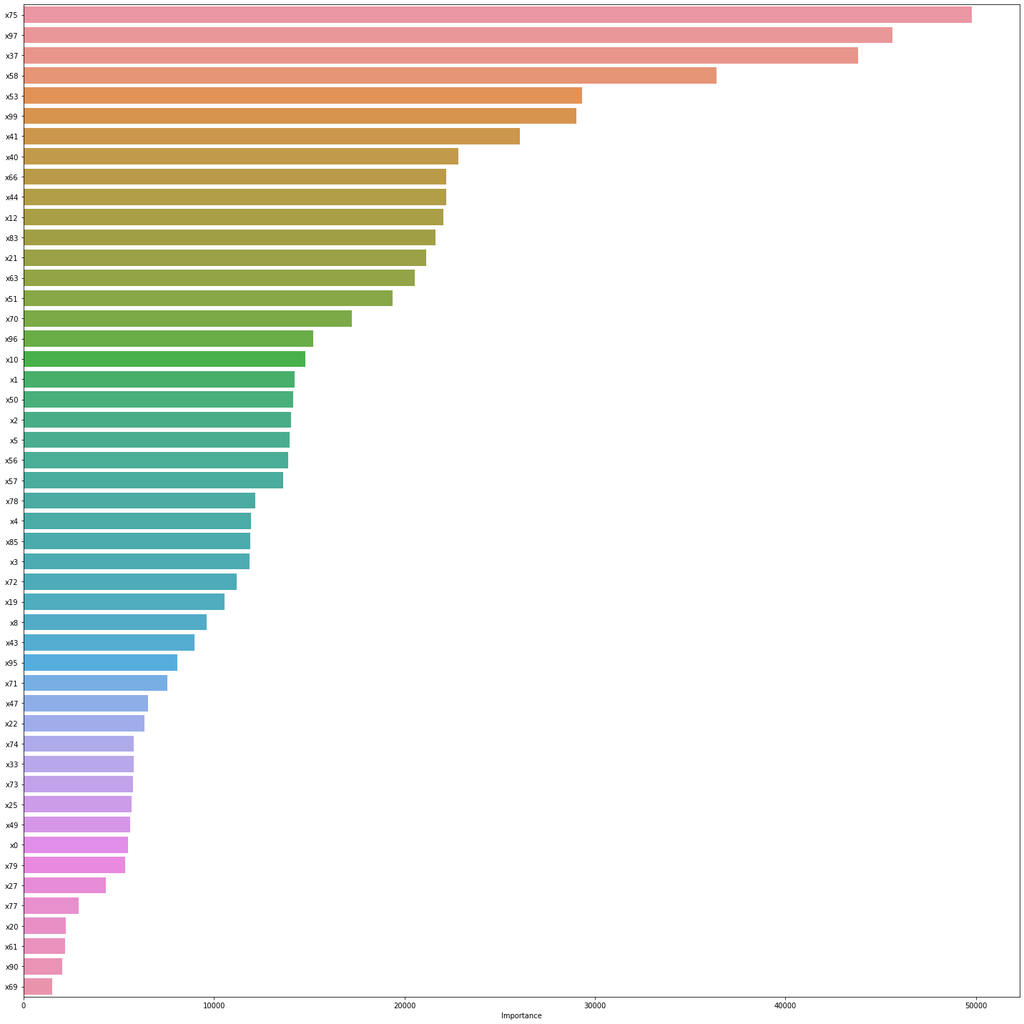

```python
lgb_fscores=pd.DataFrame(lgb_tuned.feature_importances_)

feats = {} # a dict to hold feature_name: feature_importance
for feature, importance in zip(X_train_best.columns, lgb_tuned.feature_importances_):
    feats[feature] = importance #add the name/value pair

lgb_importances = pd.DataFrame.from_dict(feats, orient='index').rename(columns={0: 'Importance'})

plt.figure(figsize=(20, 20))
importances=lgb_importances.sort_values(by='Importance', ascending=False)
sns.barplot(x='Importance', y=importances.index, data=importances)
plt.tight_layout()
```

The top important features are x37, x75, x97, x58, x53, x99 and x41, which is roughly consistent with the insights based on data visualiztion. The top rank features and the bottom rank features are quite similiar to those resulted from RandomForestCalssifier.

### Summary of models

```python
model_eval=pd.DataFrame()
model_eval['Train ROC_AUC']=[0.936, 0.977]
model_eval['Val ROC_AUC']=[0.932, 0.97]
model_eval.rename(index={0:'RandomForest', 1:'LGBM'})
```

|  | Train ROC_AUC | Val ROC_AUC |
| --- | --- | --- |
| RandomForest | 0.936 | 0.932 |
| LGBM | 0.977 | 0.970 |

The performance of these two models is pretty good, but LGBClassfier is better than RandomForestClassifier, according to the metrics - AUC.

## Prediction

### Prediction on test with two models

```python
X_test=X_test[best_features]
y_pred_rf = rf_tuned.predict_proba(X_test)

y_pred_lgb=lgb_tuned.predict_proba(X_test)
```

### Write into CSV file

```python
rf_submission=pd.DataFrame()
rf_submission['Probalities']=y_pred_rf[:,1]

lgb_submission=pd.DataFrame()
lgb_submission['Probalities']=y_pred_lgb[:,1]


rf_submission.to_csv('results1.csv')
lgb_submission.to_csv('results2.csv')
```

## Conclusion

Based on the dataset and the very limited information, I have built two classifiers: RandomForest and light GBM classifiers. According to the metrics -- AUC, I believe this two models are good enough to make accurate prediction on test data.

If I have more time, I'd like to do:

1. tune more hyperparameters for both models to get higher AUC.
2. explore features carefully, like outliers detection.
3. try more method for feature selection, such as use importances to select features, chi-square test, and other more complex methods.
4. scale all features before training model with several scalers. (Actually, I tried one method, but it didn't improve the model performance.)
5. built more models, and ensemble them to get better prediction.

Since there is no data description, I couldn't know the real names of the features, the context of the data and the bussiness goal. If I have full information, I belive I can do much better work. For example, do EDA much more deeply, use domain knowledge to do feature engineering and feature selection, and select more precise metrics to evaluate models.